# Risk Factor Analysis

## Outcome Variable

**Outcome Variable:** sstunted

## Predictor Variables

**Intervention Variable:** hhwealth_quart

**Adjustment Set:**

unadjusted

## Stratifying Variables

The analysis was stratified on these variable(s):

- agecat
- studyid
- country

## Data Summary

| agecat | studyid | country | hhwealth_quart | sstunted | n_cell | n |
| --- | --- | --- | --- | --- | --- | --- |
| Birth | COHORTS | GUATEMALA | Wealth Q4 | 0 | 291 | 816 |
| Birth | COHORTS | GUATEMALA | Wealth Q4 | 1 | 2 | 816 |
| Birth | COHORTS | GUATEMALA | Wealth Q1 | 0 | 157 | 816 |
| Birth | COHORTS | GUATEMALA | Wealth Q1 | 1 | 0 | 816 |
| Birth | COHORTS | GUATEMALA | Wealth Q2 | 0 | 158 | 816 |
| Birth | COHORTS | GUATEMALA | Wealth Q2 | 1 | 3 | 816 |
| Birth | COHORTS | GUATEMALA | Wealth Q3 | 0 | 201 | 816 |
| Birth | COHORTS | GUATEMALA | Wealth Q3 | 1 | 4 | 816 |
| Birth | COHORTS | PHILIPPINES | Wealth Q4 | 0 | 835 | 3049 |
| Birth | COHORTS | PHILIPPINES | Wealth Q4 | 1 | 7 | 3049 |
| Birth | COHORTS | PHILIPPINES | Wealth Q1 | 0 | 675 | 3049 |
| Birth | COHORTS | PHILIPPINES | Wealth Q1 | 1 | 12 | 3049 |
| Birth | COHORTS | PHILIPPINES | Wealth Q2 | 0 | 524 | 3049 |
| Birth | COHORTS | PHILIPPINES | Wealth Q2 | 1 | 14 | 3049 |
| Birth | COHORTS | PHILIPPINES | Wealth Q3 | 0 | 969 | 3049 |
| Birth | COHORTS | PHILIPPINES | Wealth Q3 | 1 | 13 | 3049 |
| 6 months | COHORTS | GUATEMALA | Wealth Q4 | 0 | 313 | 925 |
| 6 months | COHORTS | GUATEMALA | Wealth Q4 | 1 | 26 | 925 |
| 6 months | COHORTS | GUATEMALA | Wealth Q1 | 0 | 147 | 925 |
| 6 months | COHORTS | GUATEMALA | Wealth Q1 | 1 | 28 | 925 |
| 6 months | COHORTS | GUATEMALA | Wealth Q2 | 0 | 165 | 925 |
| 6 months | COHORTS | GUATEMALA | Wealth Q2 | 1 | 30 | 925 |
| 6 months | COHORTS | GUATEMALA | Wealth Q3 | 0 | 181 | 925 |
| 6 months | COHORTS | GUATEMALA | Wealth Q3 | 1 | 35 | 925 |
| 6 months | COHORTS | PHILIPPINES | Wealth Q4 | 0 | 719 | 2708 |
| 6 months | COHORTS | PHILIPPINES | Wealth Q4 | 1 | 24 | 2708 |
| 6 months | COHORTS | PHILIPPINES | Wealth Q1 | 0 | 540 | 2708 |
| 6 months | COHORTS | PHILIPPINES | Wealth Q1 | 1 | 30 | 2708 |
| 6 months | COHORTS | PHILIPPINES | Wealth Q2 | 0 | 459 | 2708 |
| 6 months | COHORTS | PHILIPPINES | Wealth Q2 | 1 | 26 | 2708 |
| 6 months | COHORTS | PHILIPPINES | Wealth Q3 | 0 | 858 | 2708 |
| 6 months | COHORTS | PHILIPPINES | Wealth Q3 | 1 | 52 | 2708 |
| 24 months | COHORTS | GUATEMALA | Wealth Q4 | 0 | 230 | 1035 |
| 24 months | COHORTS | GUATEMALA | Wealth Q4 | 1 | 172 | 1035 |
| 24 months | COHORTS | GUATEMALA | Wealth Q1 | 0 | 89 | 1035 |
| 24 months | COHORTS | GUATEMALA | Wealth Q1 | 1 | 113 | 1035 |
| 24 months | COHORTS | GUATEMALA | Wealth Q2 | 0 | 100 | 1035 |
| 24 months | COHORTS | GUATEMALA | Wealth Q2 | 1 | 112 | 1035 |
| 24 months | COHORTS | GUATEMALA | Wealth Q3 | 0 | 110 | 1035 |
| 24 months | COHORTS | GUATEMALA | Wealth Q3 | 1 | 109 | 1035 |
| 24 months | COHORTS | PHILIPPINES | Wealth Q4 | 0 | 568 | 2445 |
| 24 months | COHORTS | PHILIPPINES | Wealth Q4 | 1 | 120 | 2445 |
| 24 months | COHORTS | PHILIPPINES | Wealth Q1 | 0 | 307 | 2445 |
| 24 months | COHORTS | PHILIPPINES | Wealth Q1 | 1 | 182 | 2445 |
| 24 months | COHORTS | PHILIPPINES | Wealth Q2 | 0 | 281 | 2445 |
| 24 months | COHORTS | PHILIPPINES | Wealth Q2 | 1 | 142 | 2445 |
| 24 months | COHORTS | PHILIPPINES | Wealth Q3 | 0 | 582 | 2445 |
| 24 months | COHORTS | PHILIPPINES | Wealth Q3 | 1 | 263 | 2445 |

The following strata were considered:

- agecat: 24 months, studyid: COHORTS, country: GUATEMALA
- agecat: 24 months, studyid: COHORTS, country: PHILIPPINES
- agecat: 6 months, studyid: COHORTS, country: GUATEMALA
- agecat: 6 months, studyid: COHORTS, country: PHILIPPINES
- agecat: Birth, studyid: COHORTS, country: GUATEMALA
- agecat: Birth, studyid: COHORTS, country: PHILIPPINES

### Dropped Strata

Some strata were dropped due to rare outcomes:

- agecat: Birth, studyid: COHORTS, country: GUATEMALA

## Methods Detail

We’re interested in the causal parameters $E[Y_a]$ for all values of $a \in \mathcal{A}$. These parameters represent the mean outcome if, possibly contrary to fact, we intervened to set all units to have $A=a$. Under the randomization and positivity assumptions, these are identified by the statistical parameters $\psi_a=E_W[E_{Y|A,W}(Y|A=a,W)]$. In addition, we’re interested in the mean of $Y$, $E[Y]$ under no intervention (the observed mean). We will estimate these parameters by using SuperLearner to fit the relevant likelihood factors – $E_{Y|A,W}(Y|A=a,W)$ and $p(A=a|W)$, and then updating our likelihood fit using a joint TMLE.

For unadjusted analyses ($W=\{\}$), initial likelihoods were estimated using Lrnr_glm to estimate the simple $E(Y|A)$ and Lrnr_mean to estimate $p(A)$. For adjusted analyses, a small library containing Lrnr_glmnet, Lrnr_xgboost, and Lrnr_mean was used.

Having estimated these parameters, we will then use the delta method to estimate relative risks and attributable risks relative to a prespecified baseline level of $A$.

# Results Detail

## Results Plots

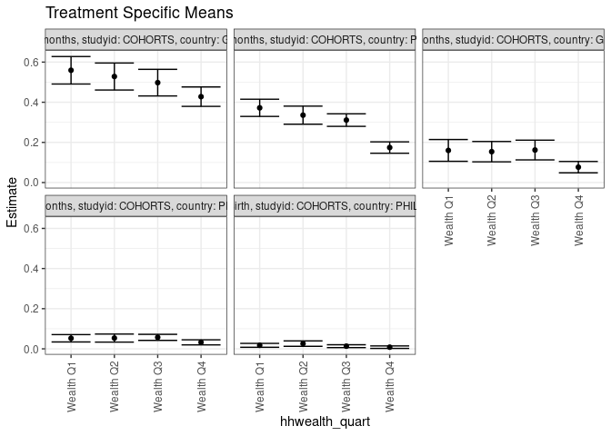

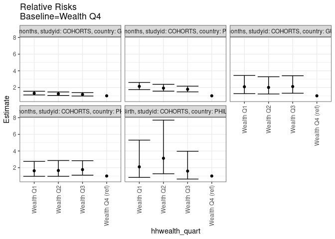

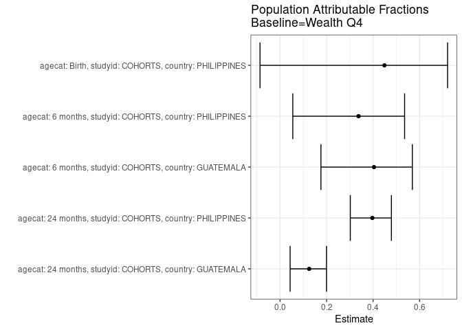

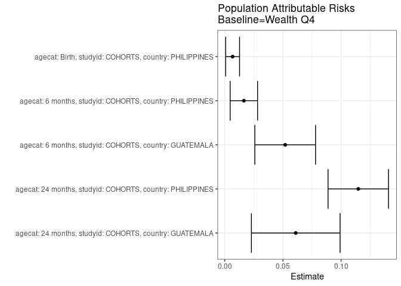

## Results Table

### Parameter: TSM

| agecat | studyid | country | intervention_level | baseline_level | estimate | ci_lower | ci_upper |
| --- | --- | --- | --- | --- | --- | --- | --- |
| Birth | COHORTS | PHILIPPINES | Wealth Q4 | NA | 0.0083135 | 0.0021795 | 0.0144475 |
| Birth | COHORTS | PHILIPPINES | Wealth Q1 | NA | 0.0174672 | 0.0076695 | 0.0272650 |
| Birth | COHORTS | PHILIPPINES | Wealth Q2 | NA | 0.0260223 | 0.0125676 | 0.0394771 |
| Birth | COHORTS | PHILIPPINES | Wealth Q3 | NA | 0.0132383 | 0.0060886 | 0.0203880 |
| 6 months | COHORTS | GUATEMALA | Wealth Q4 | NA | 0.0766962 | 0.0483534 | 0.1050389 |
| 6 months | COHORTS | GUATEMALA | Wealth Q1 | NA | 0.1600000 | 0.1056545 | 0.2143455 |
| 6 months | COHORTS | GUATEMALA | Wealth Q2 | NA | 0.1538462 | 0.1031782 | 0.2045141 |
| 6 months | COHORTS | GUATEMALA | Wealth Q3 | NA | 0.1620370 | 0.1128698 | 0.2112043 |
| 6 months | COHORTS | PHILIPPINES | Wealth Q4 | NA | 0.0323015 | 0.0195865 | 0.0450164 |
| 6 months | COHORTS | PHILIPPINES | Wealth Q1 | NA | 0.0526316 | 0.0342969 | 0.0709663 |
| 6 months | COHORTS | PHILIPPINES | Wealth Q2 | NA | 0.0536082 | 0.0335585 | 0.0736580 |
| 6 months | COHORTS | PHILIPPINES | Wealth Q3 | NA | 0.0571429 | 0.0420590 | 0.0722267 |
| 24 months | COHORTS | GUATEMALA | Wealth Q4 | NA | 0.4278607 | 0.3794717 | 0.4762497 |
| 24 months | COHORTS | GUATEMALA | Wealth Q1 | NA | 0.5594059 | 0.4909099 | 0.6279019 |
| 24 months | COHORTS | GUATEMALA | Wealth Q2 | NA | 0.5283019 | 0.4610719 | 0.5955319 |
| 24 months | COHORTS | GUATEMALA | Wealth Q3 | NA | 0.4977169 | 0.4314645 | 0.5639693 |
| 24 months | COHORTS | PHILIPPINES | Wealth Q4 | NA | 0.1744186 | 0.1460578 | 0.2027794 |
| 24 months | COHORTS | PHILIPPINES | Wealth Q1 | NA | 0.3721881 | 0.3293354 | 0.4150409 |
| 24 months | COHORTS | PHILIPPINES | Wealth Q2 | NA | 0.3356974 | 0.2906859 | 0.3807089 |
| 24 months | COHORTS | PHILIPPINES | Wealth Q3 | NA | 0.3112426 | 0.2800184 | 0.3424668 |

### Parameter: E(Y)

| agecat | studyid | country | intervention_level | baseline_level | estimate | ci_lower | ci_upper |
| --- | --- | --- | --- | --- | --- | --- | --- |
| Birth | COHORTS | PHILIPPINES | NA | NA | 0.0150869 | 0.0107594 | 0.0194144 |
| 6 months | COHORTS | GUATEMALA | NA | NA | 0.1286486 | 0.1070607 | 0.1502366 |
| 6 months | COHORTS | PHILIPPINES | NA | NA | 0.0487445 | 0.0406327 | 0.0568562 |
| 24 months | COHORTS | GUATEMALA | NA | NA | 0.4888889 | 0.4584204 | 0.5193574 |
| 24 months | COHORTS | PHILIPPINES | NA | NA | 0.2891616 | 0.2711872 | 0.3071359 |

### Parameter: RR

| agecat | studyid | country | intervention_level | baseline_level | estimate | ci_lower | ci_upper |
| --- | --- | --- | --- | --- | --- | --- | --- |
| Birth | COHORTS | PHILIPPINES | Wealth Q4 | Wealth Q4 | 1.000000 | 1.0000000 | 1.000000 |
| Birth | COHORTS | PHILIPPINES | Wealth Q1 | Wealth Q4 | 2.101060 | 0.8316064 | 5.308347 |
| Birth | COHORTS | PHILIPPINES | Wealth Q2 | Wealth Q4 | 3.130111 | 1.2713841 | 7.706246 |
| Birth | COHORTS | PHILIPPINES | Wealth Q3 | Wealth Q4 | 1.592377 | 0.6381739 | 3.973313 |
| 6 months | COHORTS | GUATEMALA | Wealth Q4 | Wealth Q4 | 1.000000 | 1.0000000 | 1.000000 |
| 6 months | COHORTS | GUATEMALA | Wealth Q1 | Wealth Q4 | 2.086154 | 1.2628777 | 3.446128 |
| 6 months | COHORTS | GUATEMALA | Wealth Q2 | Wealth Q4 | 2.005917 | 1.2227421 | 3.290722 |
| 6 months | COHORTS | GUATEMALA | Wealth Q3 | Wealth Q4 | 2.112714 | 1.3097221 | 3.408020 |
| 6 months | COHORTS | PHILIPPINES | Wealth Q4 | Wealth Q4 | 1.000000 | 1.0000000 | 1.000000 |
| 6 months | COHORTS | PHILIPPINES | Wealth Q1 | Wealth Q4 | 1.629386 | 0.9632513 | 2.756185 |
| 6 months | COHORTS | PHILIPPINES | Wealth Q2 | Wealth Q4 | 1.659622 | 0.9642640 | 2.856422 |
| 6 months | COHORTS | PHILIPPINES | Wealth Q3 | Wealth Q4 | 1.769048 | 1.1013026 | 2.841662 |
| 24 months | COHORTS | GUATEMALA | Wealth Q4 | Wealth Q4 | 1.000000 | 1.0000000 | 1.000000 |
| 24 months | COHORTS | GUATEMALA | Wealth Q1 | Wealth Q4 | 1.307449 | 1.1067137 | 1.544593 |
| 24 months | COHORTS | GUATEMALA | Wealth Q2 | Wealth Q4 | 1.234752 | 1.0414571 | 1.463923 |
| 24 months | COHORTS | GUATEMALA | Wealth Q3 | Wealth Q4 | 1.163269 | 0.9768365 | 1.385282 |
| 24 months | COHORTS | PHILIPPINES | Wealth Q4 | Wealth Q4 | 1.000000 | 1.0000000 | 1.000000 |
| 24 months | COHORTS | PHILIPPINES | Wealth Q1 | Wealth Q4 | 2.133879 | 1.7484027 | 2.604342 |
| 24 months | COHORTS | PHILIPPINES | Wealth Q2 | Wealth Q4 | 1.924665 | 1.5589250 | 2.376212 |
| 24 months | COHORTS | PHILIPPINES | Wealth Q3 | Wealth Q4 | 1.784458 | 1.4741107 | 2.160142 |

### Parameter: PAR

| agecat | studyid | country | intervention_level | baseline_level | estimate | ci_lower | ci_upper |
| --- | --- | --- | --- | --- | --- | --- | --- |
| Birth | COHORTS | PHILIPPINES | Wealth Q4 | NA | 0.0067734 | 0.0008091 | 0.0127376 |
| 6 months | COHORTS | GUATEMALA | Wealth Q4 | NA | 0.0519525 | 0.0258652 | 0.0780398 |
| 6 months | COHORTS | PHILIPPINES | Wealth Q4 | NA | 0.0164430 | 0.0046635 | 0.0282224 |
| 24 months | COHORTS | GUATEMALA | Wealth Q4 | NA | 0.0610282 | 0.0229372 | 0.0991192 |
| 24 months | COHORTS | PHILIPPINES | Wealth Q4 | NA | 0.1147429 | 0.0887670 | 0.1407189 |

### Parameter: PAF

| agecat | studyid | country | intervention_level | baseline_level | estimate | ci_lower | ci_upper |
| --- | --- | --- | --- | --- | --- | --- | --- |
| Birth | COHORTS | PHILIPPINES | Wealth Q4 | NA | 0.4489569 | -0.0865616 | 0.7205419 |
| 6 months | COHORTS | GUATEMALA | Wealth Q4 | NA | 0.4038323 | 0.1756190 | 0.5688694 |
| 6 months | COHORTS | PHILIPPINES | Wealth Q4 | NA | 0.3373302 | 0.0545516 | 0.5355313 |
| 24 months | COHORTS | GUATEMALA | Wealth Q4 | NA | 0.1248304 | 0.0430578 | 0.1996154 |
| 24 months | COHORTS | PHILIPPINES | Wealth Q4 | NA | 0.3968126 | 0.3019648 | 0.4787726 |